# Taller 5

Análisis Estadístico de Datos en Salud

PFC 2023 -– IETSI, EsSalud

Autores/as

Percy Soto-Becerra

Anthony Romero

Fecha de publicación

09-06-2023

## 1 Introducción

En este quinto taller del curso continuaremos revisando funciones para el análisis descriptivo de datos con paquetes como `Dplyr` y `Janitor` de `Tidyverse`, además revisaremos los paquetes `gtsummary`, `gmodels` y `Hmisc`.

-Lectura sugerida: [Link](https://bookdown.org/content/b298e479-b1ab-49fa-b83d-a57c2b034d49/ranking.html)

## 2 Cargar paquetes

```r
# Antes de cargar estos paquetes, se deben instalar desde la pestaña "Packages" en el panel de utilidades (inferior derecho).
library(tidyverse)                   # Varias funciones de tidyverse (dplyr, ggplot2, etc.)
library(rio)                         # Navaja suiza de la importación de datos
library(skimr)                       # Análisis inicial de datos
library(Hmisc)                       # Análisis inicial de datos
library(janitor)                     # Para identificar duplicados
library(gtsummary)                   # Para tablas estadísticas reproducibles
library(gmodels)                     # Para tablas de contingencia detalladas
library(summarytools)
```

## 3 Importar bases de datos

Utilicemos lo aprendido en sesiones previas para importar los datos de `linelist_cleaned` con el nombre **“data_ebola”** y de `boost_inmuno` con el nombre **“data_inmuno”**. Ambas son bases de datos libres tomadas del libro [The Epidemiologist R handbook](https://epirhandbook.com/en/index.html) y del estudio titulado “Immunogenicity and reactogenicity of a third dose of BNT162b2 vaccine for COVID-19 after a primary regimen with BBIBP-CorV or BNT162b2 vaccines in Lima, Peru” ([DOI](https://doi.org/10.1101/2022.05.01.22274548)), respectivamente.

**Recordar**

En sesiones previas aprendimos que antes de importar cualquier base de datos a nuestro R, debemos tener claro dos aspectos:

1. La ubicación del archivo -> Debe estar guardado en la misma carpeta del proyecto.
2. La extensión de la base -> Verificar si es formato stata (.dta), excel (.xlsx), spss (.sav), etc.

*y no olvidar que en la función `import()` se debe incluir tanto el nombre de la base como su extensión.*

Ahora importemos ambas bases:

```r
#Importamos linelist_cleaned
data_ebola <- import("linelist_cleaned.rds")

#Importamos boost_inmuno
data_inmuno <- import("boost_inmuno.dta")
```

Antes de empezar, démosle un vistazo a las bases de datos importadas:

**Explorando la data**

**Data_ebola**

```r
head(data_ebola)
```

```
  case_id generation date_infection date_onset date_hospitalisation
1  5fe599          4     2014-05-08 2014-05-13           2014-05-15
2  8689b7          4           <NA> 2014-05-13           2014-05-14
3  11f8ea          2           <NA> 2014-05-16           2014-05-18
4  b8812a          3     2014-05-04 2014-05-18           2014-05-20
5  893f25          3     2014-05-18 2014-05-21           2014-05-22
6  be99c8          3     2014-05-03 2014-05-22           2014-05-23
  date_outcome outcome gender age age_unit age_years age_cat age_cat5
1         <NA>    <NA>      m   2    years         2     0-4      0-4
2   2014-05-18 Recover      f   3    years         3     0-4      0-4
3   2014-05-30 Recover      m  56    years        56   50-69    55-59
4         <NA>    <NA>      f  18    years        18   15-19    15-19
5   2014-05-29 Recover      m   3    years         3     0-4      0-4
6   2014-05-24 Recover      f  16    years        16   15-19    15-19
                              hospital       lon      lat infector source wt_kg
```

[output cut: 20 more lines]

```r
glimpse(data_ebola)
```

```
Rows: 5,888
Columns: 30
$ case_id              <chr> "5fe599", "8689b7", "11f8ea", "b8812a", "893f25",…
$ generation           <dbl> 4, 4, 2, 3, 3, 3, 4, 4, 4, 4, 4, 4, 6, 5, 6, 9, 1…
$ date_infection       <date> 2014-05-08, NA, NA, 2014-05-04, 2014-05-18, 2014…
$ date_onset           <date> 2014-05-13, 2014-05-13, 2014-05-16, 2014-05-18, …
$ date_hospitalisation <date> 2014-05-15, 2014-05-14, 2014-05-18, 2014-05-20, …
$ date_outcome         <date> NA, 2014-05-18, 2014-05-30, NA, 2014-05-29, 2014…
$ outcome              <chr> NA, "Recover", "Recover", NA, "Recover", "Recover…
$ gender               <chr> "m", "f", "m", "f", "m", "f", "f", "f", "m", "f",…
$ age                  <dbl> 2, 3, 56, 18, 3, 16, 16, 0, 61, 27, 12, 42, 19, 7…
$ age_unit             <chr> "years", "years", "years", "years", "years", "yea…
$ age_years            <dbl> 2, 3, 56, 18, 3, 16, 16, 0, 61, 27, 12, 42, 19, 7…
$ age_cat              <fct> 0-4, 0-4, 50-69, 15-19, 0-4, 15-19, 15-19, 0-4, 5…
$ age_cat5             <fct> 0-4, 0-4, 55-59, 15-19, 0-4, 15-19, 15-19, 0-4, 6…
```

[output cut: 17 more lines]

```r
data_ebola %>%
  skim()
```

Data summary

| Name | Piped data |
| --- | --- |
| Number of rows | 5888 |
| Number of columns | 30 |
| _______________________ |  |
| Column type frequency: |  |
| character | 13 |
| Date | 4 |
| factor | 2 |
| numeric | 11 |
| ________________________ |  |
| Group variables | None |

**Variable type: character**

| skim_variable | n_missing | complete_rate | min | max | empty | n_unique | whitespace |
| --- | --- | --- | --- | --- | --- | --- | --- |
| case_id | 0 | 1.00 | 6 | 6 | 0 | 5888 | 0 |
| outcome | 1323 | 0.78 | 5 | 7 | 0 | 2 | 0 |
| gender | 278 | 0.95 | 1 | 1 | 0 | 2 | 0 |
| age_unit | 0 | 1.00 | 5 | 6 | 0 | 2 | 0 |
| hospital | 0 | 1.00 | 5 | 36 | 0 | 6 | 0 |
| infector | 2088 | 0.65 | 6 | 6 | 0 | 2697 | 0 |
| source | 2088 | 0.65 | 5 | 7 | 0 | 2 | 0 |
| fever | 249 | 0.96 | 2 | 3 | 0 | 2 | 0 |
| chills | 249 | 0.96 | 2 | 3 | 0 | 2 | 0 |
| cough | 249 | 0.96 | 2 | 3 | 0 | 2 | 0 |
| aches | 249 | 0.96 | 2 | 3 | 0 | 2 | 0 |
| vomit | 249 | 0.96 | 2 | 3 | 0 | 2 | 0 |
| time_admission | 765 | 0.87 | 5 | 5 | 0 | 1072 | 0 |

**Variable type: Date**

| skim_variable | n_missing | complete_rate | min | max | median | n_unique |
| --- | --- | --- | --- | --- | --- | --- |
| date_infection | 2087 | 0.65 | 2014-03-19 | 2015-04-27 | 2014-10-11 | 359 |
| date_onset | 256 | 0.96 | 2014-04-07 | 2015-04-30 | 2014-10-23 | 367 |
| date_hospitalisation | 0 | 1.00 | 2014-04-17 | 2015-04-30 | 2014-10-23 | 363 |
| date_outcome | 936 | 0.84 | 2014-04-19 | 2015-06-04 | 2014-11-01 | 371 |

**Variable type: factor**

| skim_variable | n_missing | complete_rate | ordered | n_unique | top_counts |
| --- | --- | --- | --- | --- | --- |
| age_cat | 86 | 0.99 | FALSE | 8 | 0-4: 1095, 5-9: 1095, 20-: 1073, 10-: 941 |
| age_cat5 | 86 | 0.99 | FALSE | 17 | 0-4: 1095, 5-9: 1095, 10-: 941, 15-: 743 |

**Variable type: numeric**

| skim_variable | n_missing | complete_rate | mean | sd | p0 | p25 | p50 | p75 | p100 | hist |
| --- | --- | --- | --- | --- | --- | --- | --- | --- | --- | --- |
| generation | 0 | 1.00 | 16.56 | 5.79 | 0.00 | 13.00 | 16.00 | 20.00 | 37.00 | ▁▆▇▂▁ |
| age | 86 | 0.99 | 16.07 | 12.62 | 0.00 | 6.00 | 13.00 | 23.00 | 84.00 | ▇▅▁▁▁ |
| age_years | 86 | 0.99 | 16.02 | 12.64 | 0.00 | 6.00 | 13.00 | 23.00 | 84.00 | ▇▅▁▁▁ |
| lon | 0 | 1.00 | -13.23 | 0.02 | -13.27 | -13.25 | -13.23 | -13.22 | -13.21 | ▅▃▃▆▇ |
| lat | 0 | 1.00 | 8.47 | 0.01 | 8.45 | 8.46 | 8.47 | 8.48 | 8.49 | ▅▇▇▇▆ |
| wt_kg | 0 | 1.00 | 52.64 | 18.58 | -11.00 | 41.00 | 54.00 | 66.00 | 111.00 | ▁▃▇▅▁ |
| ht_cm | 0 | 1.00 | 124.96 | 49.52 | 4.00 | 91.00 | 129.00 | 159.00 | 295.00 | ▂▅▇▂▁ |
| ct_blood | 0 | 1.00 | 21.21 | 1.69 | 16.00 | 20.00 | 22.00 | 22.00 | 26.00 | ▁▃▇▃▁ |
| temp | 149 | 0.97 | 38.56 | 0.98 | 35.20 | 38.20 | 38.80 | 39.20 | 40.80 | ▁▂▂▇▁ |
| bmi | 0 | 1.00 | 46.89 | 55.39 | -1200.00 | 24.56 | 32.12 | 50.01 | 1250.00 | ▁▁▇▁▁ |
| days_onset_hosp | 256 | 0.96 | 2.06 | 2.26 | 0.00 | 1.00 | 1.00 | 3.00 | 22.00 | ▇▁▁▁▁ |

**Data_inmuno**

```r
head(data_inmuno)
```

```
  id edad sexo comorb tipo_refuerzo tdosis_refuerzo ant_COV IgG_Basal IgG_Final
1  1   23    0      0    Heterologo             233       1     99.79    554.63
2  2   24    1      0    Heterologo             232       1     41.34    549.02
3  3   24   NA      0    Heterologo             242       0    413.50    485.43
4  4   23    0      0    Heterologo             234       0     13.42    573.46
5  5   24    0      0    Heterologo             236       1      4.83    473.81
6  6   26    0      0    Heterologo             241       1     21.70    603.79
```

```r
glimpse(data_inmuno)
```

```
Rows: 285
Columns: 9
$ id              <dbl> 1, 2, 3, 4, 5, 6, 7, 8, 9, 10, 11, 12, 13, 14, 15, 16,…
$ edad            <dbl> 23, 24, 24, 23, 24, 26, 25, 27, 25, 26, 28, 28, 27, 29…
$ sexo            <dbl> 0, 1, NA, 0, 0, 0, 0, 0, 0, 0, 0, 1, 1, 0, 0, 0, 1, 0,…
$ comorb          <dbl> 0, 0, 0, 0, 0, 0, 0, 0, 0, 0, 0, 0, 0, 0, 0, 0, 0, 0, …
$ tipo_refuerzo   <chr> "Heterologo", "Heterologo", "Heterologo", "Heterologo"…
$ tdosis_refuerzo <dbl> 233, 232, 242, 234, 236, 241, 201, 241, 212, 239, 246,…
$ ant_COV         <dbl> 1, 1, 0, 0, 1, 1, 0, 1, 0, 0, 0, 1, 0, 1, 0, 0, 0, 0, …
$ IgG_Basal       <dbl> 99.79, 41.34, 413.50, 13.42, 4.83, 21.70, 8.70, 10.81,…
$ IgG_Final       <dbl> 554.63, 549.02, 485.43, 573.46, 473.81, 603.79, 532.84…
```

```r
data_inmuno %>%
  skim()
```

Data summary

| Name | Piped data |
| --- | --- |
| Number of rows | 285 |
| Number of columns | 9 |
| _______________________ |  |
| Column type frequency: |  |
| character | 1 |
| numeric | 8 |
| ________________________ |  |
| Group variables | None |

**Variable type: character**

| skim_variable | n_missing | complete_rate | min | max | empty | n_unique | whitespace |
| --- | --- | --- | --- | --- | --- | --- | --- |
| tipo_refuerzo | 0 | 1 | 0 | 10 | 1 | 3 | 0 |

**Variable type: numeric**

| skim_variable | n_missing | complete_rate | mean | sd | p0 | p25 | p50 | p75 | p100 | hist |
| --- | --- | --- | --- | --- | --- | --- | --- | --- | --- | --- |
| id | 0 | 1 | 143.00 | 82.42 | 1.00 | 72.00 | 143.00 | 214.00 | 285.00 | ▇▇▇▇▇ |
| edad | 0 | 1 | 48.25 | 14.71 | 23.00 | 36.00 | 46.00 | 59.00 | 97.00 | ▇▇▇▂▁ |
| sexo | 1 | 1 | 0.33 | 0.47 | 0.00 | 0.00 | 0.00 | 1.00 | 1.00 | ▇▁▁▁▅ |
| comorb | 0 | 1 | 0.25 | 0.43 | 0.00 | 0.00 | 0.00 | 0.00 | 1.00 | ▇▁▁▁▂ |
| tdosis_refuerzo | 0 | 1 | 214.47 | 25.28 | 134.00 | 199.00 | 222.00 | 235.00 | 267.00 | ▁▂▃▇▁ |
| ant_COV | 0 | 1 | 0.29 | 0.46 | 0.00 | 0.00 | 0.00 | 1.00 | 1.00 | ▇▁▁▁▃ |
| IgG_Basal | 1 | 1 | 82.54 | 122.33 | -2.19 | 8.15 | 28.33 | 96.33 | 583.97 | ▇▁▁▁▁ |
| IgG_Final | 0 | 1 | 492.26 | 71.15 | 235.51 | 447.18 | 501.20 | 545.15 | 618.44 | ▁▁▃▇▅ |

## 4 Análisis descriptivo univariado de datos numéricos

### Ejercicio 1

Calcular la media “IgG_Basal”:

*¿Cómo interpretarías los resultados encontrados? (discutirlo en la sesión)*

**Solución**

```r
data_inmuno %>%
  summarise(media_IgG_basal = mean(IgG_Basal, na.rm = TRUE))
```

```
  media_IgG_basal
1        82.54356
```

### Ejercicio 2

Calcular la mediana y desviación estándar de la IgG_Final:

*¿Cómo interpretarías los resultados encontrados? (discutirlo en la sesión)*

**Solución**

```r
data_inmuno %>%
  summarise(mediana_IgG_final = median(IgG_Final, na.rm = TRUE),
            DE_IgG_final = sd(IgG_Final, na.rm= TRUE))
```

```
  mediana_IgG_final DE_IgG_final
1             501.2     71.14954
```

### Ejercicio 3

Calcular la media, desviación estándar, mediana, P25 y P75 del tiempo de dosis de refuerzo:

*¿Cómo interpretarías los resultados encontrados? (discutirlo en la sesión)*

**Solución**

```r
data_inmuno %>%
  summarise(media_tref = mean(tdosis_refuerzo, na.rm = TRUE),
            DE_tref = sd(tdosis_refuerzo, na.rm = TRUE),
            mediana_tref = median(tdosis_refuerzo, na.rm = TRUE),
            p25_tref = quantile(tdosis_refuerzo, na.rm = TRUE, prob = c(0.25)),
            p75_tref = quantile(tdosis_refuerzo, na.rm = TRUE, prob = c(0.75)))
```

```
  media_tref  DE_tref mediana_tref p25_tref p75_tref
1   214.4702 25.27573          222      199      235
```

### Ejercicio 4

Calcular la media, desviación estándar, mediana, P25 y P75 de la variable “edad”:

*¿Cómo interpretarías los resultados encontrados? (discutirlo en la sesión)*

**Solución**

```r
data_inmuno %>%
  summarise(media_edad = mean(edad, na.rm = TRUE),
            DE_edad = sd(edad, na.rm = TRUE),
            mediana_edad = median(edad, na.rm = TRUE),
            p25_edad = quantile(edad, na.rm = TRUE, prob = c(0.25)),
            p75_edad = quantile(edad, na.rm = TRUE, prob = c(0.75)))
```

```
  media_edad  DE_edad mediana_edad p25_edad p75_edad
1   48.24561 14.70901           46       36       59
```

### Ejercicio 5

Calcula la media, mediana y desviación estándar de edad y de IgG_Final:

*¿Cómo interpretarías los resultados encontrados? (discutirlo en la sesión)*

**Solución**

```r
data_inmuno %>%
  summarise(media_edad = mean(edad, na.rm = TRUE),
            DE_edad = sd(edad, na.rm = TRUE),
            mediana_edad = median(edad, na.rm = TRUE),
            media_IgG_final = mean(IgG_Final, na.rm = TRUE),
            DE_IgG_Final = sd(IgG_Final, na.rm = TRUE),
            mediana_IgG_final = median(IgG_Final, na.rm = TRUE))
```

```
  media_edad  DE_edad mediana_edad media_IgG_final DE_IgG_Final
1   48.24561 14.70901           46        492.2573     71.14954
  mediana_IgG_final
1             501.2
```

### Ejercicio 6

Calcula la media, mediana y desviación estándar de edad y del tiempo de dosis de refuerzo:

*¿Cómo interpretarías los resultados encontrados? (discutirlo en la sesión)*

**Solución**

```r
data_inmuno %>%
  summarise(media_edad = mean(edad, na.rm = TRUE),
            DE_edad = sd(edad, na.rm = TRUE),
            mediana_edad = median(edad, na.rm = TRUE),
            media_tref = mean(tdosis_refuerzo, na.rm = TRUE),
            DE_tref = sd(tdosis_refuerzo, na.rm = TRUE),
            mediana_tref = median(tdosis_refuerzo, na.rm = TRUE))
```

```
  media_edad  DE_edad mediana_edad media_tref  DE_tref mediana_tref
1   48.24561 14.70901           46   214.4702 25.27573          222
```

## 5 Análisis descriptivo bivariado de datos numéricos

### Ejercicio 7

**Recordatorio!**

Como buenas prácticas en programación en R, si usamos la función `group_by()` **es obligatorio usar la función `ungroup()` después del `summarise()`.** Esto permite deshacer el agrupamiento inicial y mantener la data en su versión original.

Veamos un ejemplo sencillo

```r
data %>%
  group_by(sexo) %>%      # Agrupamos según sexo
  summarise(media_edad = mean(edad, na.rm=TRUE),
            mediana_edad = median(edad, na.rm=TRUE)) %>%
  ungroup()     # Deshacemos el agrupamiento para volver a la data original
```

*¿Cómo interpretarías los resultados encontrados? (discutirlo en la sesión)*

**Solución**

```r
data_inmuno %>%
  group_by(sexo) %>%
  summarise(media_IgG_basal = mean(IgG_Basal, na.rm = TRUE),
            DE_IgG_basal = sd(IgG_Basal, na.rm = TRUE),
            mediana_IgG_basal = median(IgG_Basal, na.rm = TRUE),
            p25_IgG_basal = quantile(IgG_Basal, na.rm = TRUE, prob = c(0.25)),
            p75_IgG_basal = quantile(IgG_Basal, na.rm = TRUE, prob = c(0.75))) %>%
  ungroup()
```

```
# A tibble: 3 × 6
   sexo media_IgG_basal DE_IgG_basal mediana_IgG_basal p25_IgG_basal
  <dbl>           <dbl>        <dbl>             <dbl>         <dbl>
1     0            72.0         111.              25.1          8.06
2     1            99.9         137.              40.7          8.57
3    NA           414.           NA              414.         414.
# ℹ 1 more variable: p75_IgG_basal <dbl>
```

### Ejercicio 8

Utilice el código de la pregunta 2 y modifíquelo de tal manera que se comparen las medidas estadísticas calculadas entre los que recibieron tipo de refuerzo heterólogo y los que recibieron refuerzo homólogo:

*¿Cómo interpretarías los resultados encontrados? (discutirlo en la sesión)*

**Solución**

```r
data_inmuno %>%
  group_by(tipo_refuerzo) %>%
  summarise(mediana_IgG_final = median(IgG_Final, na.rm = TRUE),
            DE_IgG_final = sd(IgG_Final, na.rm= TRUE)) %>%
  ungroup()
```

```
# A tibble: 3 × 3
  tipo_refuerzo mediana_IgG_final DE_IgG_final
  <chr>                     <dbl>        <dbl>
1 ""                         378.         NA
2 "Heterologo"               518.         58.6
3 "Homologo"                 420.         74.2
```

### Ejercicio 9

Utilice el código de la pregunta 3 y modifíquelo de tal manera que se comparen las medidas estadísticas calculadas según antecedente de COVID-19:

*¿Cómo interpretarías los resultados encontrados? (discutirlo en la sesión)*

**Solución**

```r
data_inmuno %>%
  group_by(ant_COV) %>%
  summarise(media_tref = mean(tdosis_refuerzo, na.rm = TRUE),
            DE_tref = sd(tdosis_refuerzo, na.rm = TRUE),
            mediana_tref = median(tdosis_refuerzo, na.rm = TRUE),
            p25_tref = quantile(tdosis_refuerzo, na.rm = TRUE, prob = c(0.25)),
            p75_tref = quantile(tdosis_refuerzo, na.rm = TRUE, prob = c(0.75))) %>%
  ungroup()
```

```
# A tibble: 2 × 6
  ant_COV media_tref DE_tref mediana_tref p25_tref p75_tref
    <dbl>      <dbl>   <dbl>        <dbl>    <dbl>    <dbl>
1       0       214.    26.0          222      196      235
2       1       217.    23.5          222      202      235
```

### Ejercicio 10

*¿Cómo interpretarías los resultados encontrados? (discutirlo en la sesión)*

**Solución**

```r
data_inmuno %>%
  group_by(sexo) %>%
  summarise(media_edad = mean(edad, na.rm = TRUE),
            DE_edad = sd(edad, na.rm = TRUE),
            mediana_edad = median(edad, na.rm = TRUE),
            media_tref = mean(tdosis_refuerzo, na.rm = TRUE),
            DE_tref = sd(tdosis_refuerzo, na.rm = TRUE),
            mediana_tref = median(tdosis_refuerzo, na.rm = TRUE))
```

```
# A tibble: 3 × 7
   sexo media_edad DE_edad mediana_edad media_tref DE_tref mediana_tref
  <dbl>      <dbl>   <dbl>        <dbl>      <dbl>   <dbl>        <dbl>
1     0       46.8    14.2           45       216.    23.3          220
2     1       51.5    15.2           51       211.    28.7          226
3    NA       24      NA             24       242     NA            242
```

## 6 Análisis descriptivo univariado de datos categóricos

### Ejercicio 11

Crear una tabla con las frecuencias absolutas usando {dplyr}. Luego cree una tabla con frecuencias absolutas y relativas usando {janitor} y relativa del sexo, primero con los NA y luego excluyendo los NA:

*¿Cómo interpretarías los resultados encontrados? (discutirlo en la sesión)*

**Solución**

- Con dplyr:

```r
data_inmuno %>%
  count(sexo)
```

```
  sexo   n
1    0 189
2    1  95
3   NA   1
```

- Con janitor:

Con NA´s

```r
data_inmuno %>%
  tabyl(sexo, show_na = TRUE)
```

```
 sexo   n     percent valid_percent
    0 189 0.663157895      0.665493
    1  95 0.333333333      0.334507
   NA   1 0.003508772            NA
```

Sin NA´s

```r
data_inmuno %>%
  tabyl(sexo, show_na = FALSE)
```

```
 sexo   n  percent
    0 189 0.665493
    1  95 0.334507
```

### Ejercicio 12

Genere una tabla descriptiva para comorbilidades usando {dplyr}, {janitor} y {summarytools}:

*¿Cómo interpretarías los resultados encontrados? (discutirlo en la sesión)*

*Compare las salidas de los tres paquetes*

**Solución**

- Con dplyr:

```r
data_inmuno %>%
  count(comorb)
```

```
  comorb   n
1      0 214
2      1  71
```

- Con janitor:

```r
data_inmuno %>%
  tabyl(comorb)
```

```
 comorb   n   percent
      0 214 0.7508772
      1  71 0.2491228
```

- Con summarytools:

```r
data_inmuno %>%
  select(comorb) %>%
  freq()
```

```
Frequencies
data_inmuno$comorb
Label: comorbilidad
Type: Numeric

              Freq   % Valid   % Valid Cum.   % Total   % Total Cum.
----------- ------ --------- -------------- --------- --------------
          0    214     75.09          75.09     75.09          75.09
          1     71     24.91         100.00     24.91         100.00
       <NA>      0                               0.00         100.00
      Total    285    100.00         100.00    100.00         100.00
```

### Ejercicio 13

Genere una tabla descriptiva para el tipo de refuerzo recibido que presente frecuencias absolutas y relativas, excluya los NA:

*¿Cómo interpretarías los resultados encontrados? (discutirlo en la sesión)*

**Solución**

```r
data_inmuno %>%
  tabyl(tipo_refuerzo)
```

```
 tipo_refuerzo   n     percent
                 1 0.003508772
    Heterologo 228 0.800000000
      Homologo  56 0.196491228
```

- Pueden hacerlo también con {dplyr} o {summarytools}

### Ejercicio 14

Genere una tabla descriptiva para antecedente de COVID-19:

*¿Cómo interpretarías los resultados encontrados? (discutirlo en la sesión)*

**Solución**

```r
data_inmuno |>
  tabyl(ant_COV)
```

```
 ant_COV   n   percent
       0 201 0.7052632
       1  84 0.2947368
```

**La opción de R base:**

- También podemos crear tablas con la opción de `R base` table().

```r
table(data_inmuno$ant_COV)
```

```
  0   1
201  84
```

## 7 Análisis descriptivo bivariado de datos categóricos

### Ejercicio 15

Genere una tabla bivariada con el sexo y el antecedente de COVID-19:

*¿Cómo interpretarías los resultados encontrados? (discutirlo en la sesión)*

**Solución**

- Opción dplyr (menos amigable):

```r
data_inmuno |>
  group_by(sexo) |>
  count(ant_COV) |>
  ungroup()
```

```
# A tibble: 5 × 3
   sexo ant_COV     n
  <dbl>   <dbl> <int>
1     0       0   133
2     0       1    56
3     1       0    67
4     1       1    28
5    NA       0     1
```

- Opción tabyl:

```r
data_inmuno |>
  tabyl(sexo, ant_COV)
```

```
 sexo   0  1
    0 133 56
    1  67 28
   NA   1  0
```

- Opción tabyl adornada:

Mostrar fila a fila como funciona.

```r
data_inmuno |>
  tabyl(sexo, ant_COV) |>
  adorn_percentages("row") |>
  adorn_pct_formatting(digits = 2) |>
  adorn_ns()
```

```
 sexo             0           1
    0  70.37% (133) 29.63% (56)
    1  70.53%  (67) 29.47% (28)
   NA 100.00%   (1)  0.00%  (0)
```

- Opción gmodels (opción recomendada para análisis inicial/exploratoria, es más rápida y directa):

```r
CrossTable(data_inmuno$sexo, data_inmuno$ant_COV)
```

```
   Cell Contents
|-------------------------|
|                       N |
| Chi-square contribution |
|           N / Row Total |
|           N / Col Total |
|         N / Table Total |
|-------------------------|


Total Observations in Table:  284


                 | data_inmuno$ant_COV
data_inmuno$sexo |         0 |         1 | Row Total |
-----------------|-----------|-----------|-----------|
               0 |       133 |        56 |       189 |
                 |     0.000 |     0.000 |           |
                 |     0.704 |     0.296 |     0.665 |
                 |     0.665 |     0.667 |           |
                 |     0.468 |     0.197 |           |
-----------------|-----------|-----------|-----------|
               1 |        67 |        28 |        95 |
                 |     0.000 |     0.000 |           |
                 |     0.705 |     0.295 |     0.335 |
                 |     0.335 |     0.333 |           |
                 |     0.236 |     0.099 |           |
-----------------|-----------|-----------|-----------|
    Column Total |       200 |        84 |       284 |
                 |     0.704 |     0.296 |           |
-----------------|-----------|-----------|-----------|
```

**Uso de $ de R base**

- {gmodels} es un paquete que se sustenta en R base.
- Por lo tanto, es necesario usar el `$` para llamar las columnas de interés para crear la tabla de contingencia.
- Aunque es molestoso estar repitiendo el nombre de la base constantemente para llamar la variable con $, el formato de sus tablas lo valen.

### Ejercicio 16

Genere una tabla bivariada entre sexo y tipo de refuerzo recibido:

*¿Cómo interpretarías los resultados encontrados? (discutirlo en la sesión)*

**Solución**

```r
CrossTable(data_inmuno$sexo, data_inmuno$tipo_refuerzo)
```

```
   Cell Contents
|-------------------------|
|                       N |
| Chi-square contribution |
|           N / Row Total |
|           N / Col Total |
|         N / Table Total |
|-------------------------|


Total Observations in Table:  284


                 | data_inmuno$tipo_refuerzo
data_inmuno$sexo |            | Heterologo |   Homologo |  Row Total |
-----------------|------------|------------|------------|------------|
               0 |          1 |        160 |         28 |        189 |
                 |      0.168 |      0.528 |      2.305 |            |
                 |      0.005 |      0.847 |      0.148 |      0.665 |
                 |      1.000 |      0.705 |      0.500 |            |
                 |      0.004 |      0.563 |      0.099 |            |
-----------------|------------|------------|------------|------------|
               1 |          0 |         67 |         28 |         95 |
                 |      0.335 |      1.051 |      4.585 |            |
                 |      0.000 |      0.705 |      0.295 |      0.335 |
                 |      0.000 |      0.295 |      0.500 |            |
                 |      0.000 |      0.236 |      0.099 |            |
-----------------|------------|------------|------------|------------|
    Column Total |          1 |        227 |         56 |        284 |
                 |      0.004 |      0.799 |      0.197 |            |
-----------------|------------|------------|------------|------------|
```

### Ejercicio 17

Genere una tabla bivariada entre comorbilidades y tipo de refuerzo recibido

*¿Cómo interpretarías los resultados encontrados? (discutirlo en la sesión)*

**Solución**

```r
CrossTable(data_inmuno$comorb, data_inmuno$tipo_refuerzo)
```

```
   Cell Contents
|-------------------------|
|                       N |
| Chi-square contribution |
|           N / Row Total |
|           N / Col Total |
|         N / Table Total |
|-------------------------|


Total Observations in Table:  285


                   | data_inmuno$tipo_refuerzo
data_inmuno$comorb |            | Heterologo |   Homologo |  Row Total |
-------------------|------------|------------|------------|------------|
                 0 |          1 |        185 |         28 |        214 |
                   |      0.083 |      1.112 |      4.694 |            |
                   |      0.005 |      0.864 |      0.131 |      0.751 |
                   |      1.000 |      0.811 |      0.500 |            |
                   |      0.004 |      0.649 |      0.098 |            |
-------------------|------------|------------|------------|------------|
                 1 |          0 |         43 |         28 |         71 |
                   |      0.249 |      3.353 |     14.148 |            |
                   |      0.000 |      0.606 |      0.394 |      0.249 |
                   |      0.000 |      0.189 |      0.500 |            |
                   |      0.000 |      0.151 |      0.098 |            |
-------------------|------------|------------|------------|------------|
      Column Total |          1 |        228 |         56 |        285 |
                   |      0.004 |      0.800 |      0.196 |            |
-------------------|------------|------------|------------|------------|
```

### Ejercicio 18

Ahora utiliza data_ebola y genera tablas bivariadas entre gender y fever, chills, cough, aches y vomit (una tabla por cada par de variables: ejm gender y fever, gender y chills, etc)

*¿Cómo interpretarías los resultados encontrados? (discutirlo en la sesión)*

**Solución**

```r
CrossTable(data_ebola$gender, data_ebola$fever)
```

```
   Cell Contents
|-------------------------|
|                       N |
| Chi-square contribution |
|           N / Row Total |
|           N / Col Total |
|         N / Table Total |
|-------------------------|


Total Observations in Table:  5371


                  | data_ebola$fever
data_ebola$gender |        no |       yes | Row Total |
------------------|-----------|-----------|-----------|
                f |       520 |      2161 |      2681 |
                  |     0.007 |     0.002 |           |
                  |     0.194 |     0.806 |     0.499 |
                  |     0.501 |     0.499 |           |
                  |     0.097 |     0.402 |           |
------------------|-----------|-----------|-----------|
                m |       518 |      2172 |      2690 |
                  |     0.007 |     0.002 |           |
                  |     0.193 |     0.807 |     0.501 |
                  |     0.499 |     0.501 |           |
                  |     0.096 |     0.404 |           |
------------------|-----------|-----------|-----------|
     Column Total |      1038 |      4333 |      5371 |
                  |     0.193 |     0.807 |           |
------------------|-----------|-----------|-----------|
```

```r
CrossTable(data_ebola$gender, data_ebola$chills)
```

```
   Cell Contents
|-------------------------|
|                       N |
| Chi-square contribution |
|           N / Row Total |
|           N / Col Total |
|         N / Table Total |
|-------------------------|


Total Observations in Table:  5371


                  | data_ebola$chills
data_ebola$gender |        no |       yes | Row Total |
------------------|-----------|-----------|-----------|
                f |      2169 |       512 |      2681 |
                  |     0.047 |     0.196 |           |
                  |     0.809 |     0.191 |     0.499 |
                  |     0.502 |     0.489 |           |
                  |     0.404 |     0.095 |           |
------------------|-----------|-----------|-----------|
                m |      2156 |       534 |      2690 |
                  |     0.047 |     0.196 |           |
                  |     0.801 |     0.199 |     0.501 |
                  |     0.498 |     0.511 |           |
                  |     0.401 |     0.099 |           |
------------------|-----------|-----------|-----------|
     Column Total |      4325 |      1046 |      5371 |
                  |     0.805 |     0.195 |           |
------------------|-----------|-----------|-----------|
```

```r
CrossTable(data_ebola$gender, data_ebola$cough)
```

```
   Cell Contents
|-------------------------|
|                       N |
| Chi-square contribution |
|           N / Row Total |
|           N / Col Total |
|         N / Table Total |
|-------------------------|


Total Observations in Table:  5371


                  | data_ebola$cough
data_ebola$gender |        no |       yes | Row Total |
------------------|-----------|-----------|-----------|
                f |       382 |      2299 |      2681 |
                  |     0.503 |     0.080 |           |
                  |     0.142 |     0.858 |     0.499 |
                  |     0.518 |     0.496 |           |
                  |     0.071 |     0.428 |           |
------------------|-----------|-----------|-----------|
                m |       356 |      2334 |      2690 |
                  |     0.502 |     0.080 |           |
                  |     0.132 |     0.868 |     0.501 |
                  |     0.482 |     0.504 |           |
                  |     0.066 |     0.435 |           |
------------------|-----------|-----------|-----------|
     Column Total |       738 |      4633 |      5371 |
                  |     0.137 |     0.863 |           |
------------------|-----------|-----------|-----------|
```

```r
CrossTable(data_ebola$gender, data_ebola$aches)
```

```
   Cell Contents
|-------------------------|
|                       N |
| Chi-square contribution |
|           N / Row Total |
|           N / Col Total |
|         N / Table Total |
|-------------------------|


Total Observations in Table:  5371


                  | data_ebola$aches
data_ebola$gender |        no |       yes | Row Total |
------------------|-----------|-----------|-----------|
                f |      2437 |       244 |      2681 |
                  |     0.065 |     0.616 |           |
                  |     0.909 |     0.091 |     0.499 |
                  |     0.502 |     0.475 |           |
                  |     0.454 |     0.045 |           |
------------------|-----------|-----------|-----------|
                m |      2420 |       270 |      2690 |
                  |     0.065 |     0.614 |           |
                  |     0.900 |     0.100 |     0.501 |
                  |     0.498 |     0.525 |           |
                  |     0.451 |     0.050 |           |
------------------|-----------|-----------|-----------|
     Column Total |      4857 |       514 |      5371 |
                  |     0.904 |     0.096 |           |
------------------|-----------|-----------|-----------|
```

```r
CrossTable(data_ebola$gender, data_ebola$vomit)
```

```
   Cell Contents
|-------------------------|
|                       N |
| Chi-square contribution |
|           N / Row Total |
|           N / Col Total |
|         N / Table Total |
|-------------------------|


Total Observations in Table:  5371


                  | data_ebola$vomit
data_ebola$gender |        no |       yes | Row Total |
------------------|-----------|-----------|-----------|
                f |      1338 |      1343 |      2681 |
                  |     0.150 |     0.152 |           |
                  |     0.499 |     0.501 |     0.499 |
                  |     0.494 |     0.505 |           |
                  |     0.249 |     0.250 |           |
------------------|-----------|-----------|-----------|
                m |      1371 |      1319 |      2690 |
                  |     0.149 |     0.152 |           |
                  |     0.510 |     0.490 |     0.501 |
                  |     0.506 |     0.495 |           |
                  |     0.255 |     0.246 |           |
------------------|-----------|-----------|-----------|
     Column Total |      2709 |      2662 |      5371 |
                  |     0.504 |     0.496 |           |
------------------|-----------|-----------|-----------|
```

## 8 Gráficos comparativos para datos numéricos y categóricos

### Ejercicio 19

Cree un gráfico de cajas comparando el IgG Final según tipo de refuero recibido. Guardelo como p1. Luego, agregue un gráfico de puntos con ruido (jittered) y guárdelo como p2. Por último, cambie la geometrái de caja por la de violin y guárdelo como p3. En todos los casos use tema minimal.

*¿Cómo interpretarías los resultados encontrados? (discutirlo en la sesión)*

*Compare p1, p2 y p3*

**Solución**

- p1:

Si no se elimina la categoría perdida pasa esto:

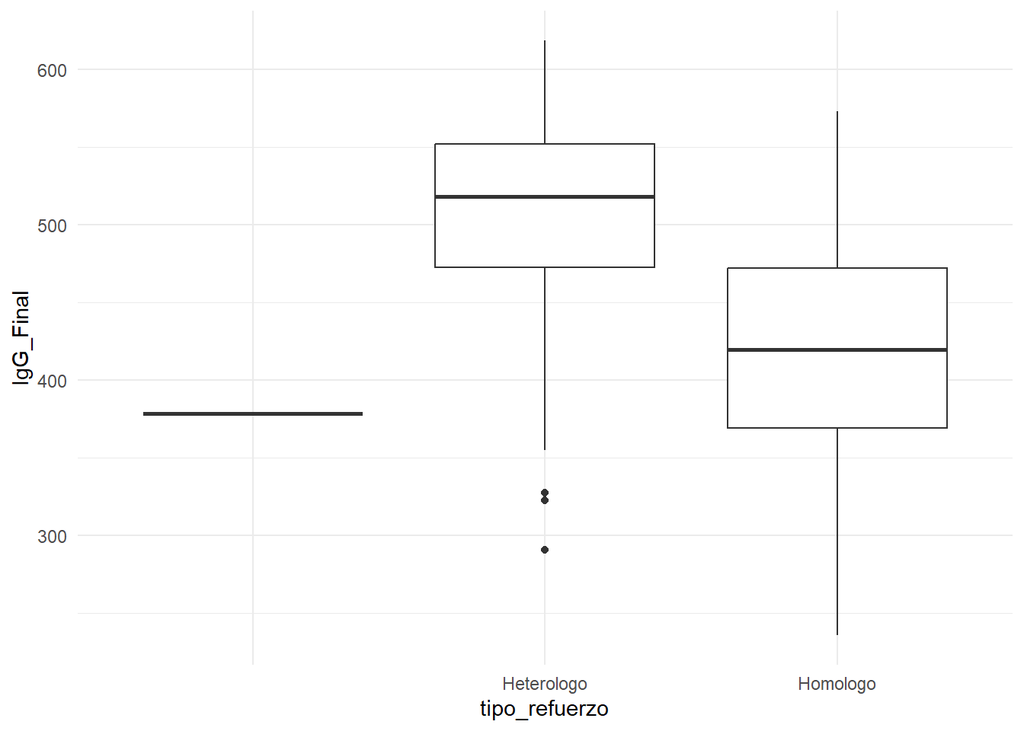

```r
p1 <- data_inmuno |>
  ggplot(aes(x = tipo_refuerzo, y = IgG_Final)) +
  geom_boxplot() +
  theme_minimal()

p1
```

Hay que eliminarla primero:

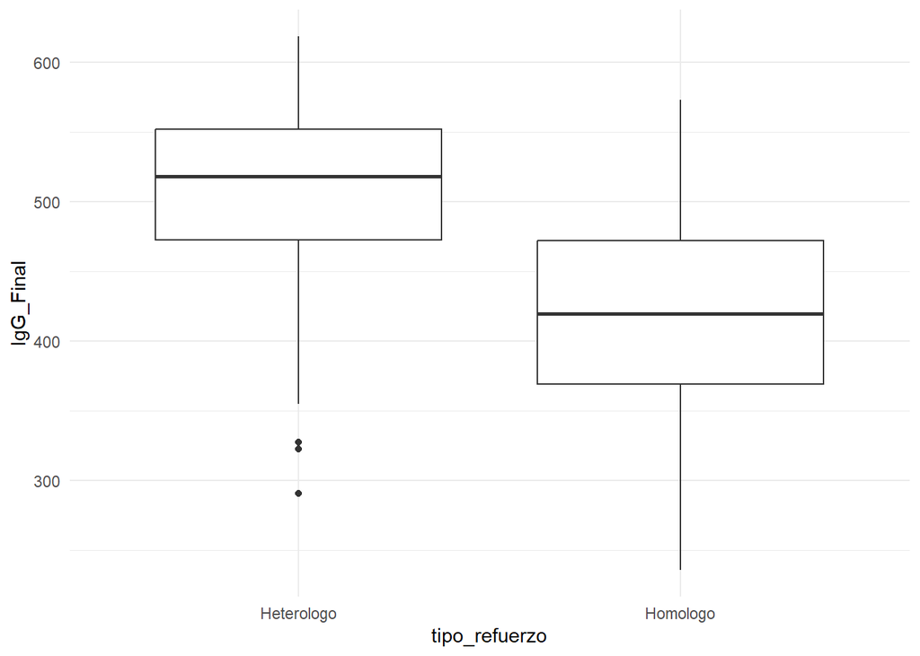

```r
p1 <- data_inmuno |>
  filter(tipo_refuerzo != "") |>
  ggplot(aes(x = tipo_refuerzo, y = IgG_Final)) +
  geom_boxplot() +
  theme_minimal()

p1
```

- p2:

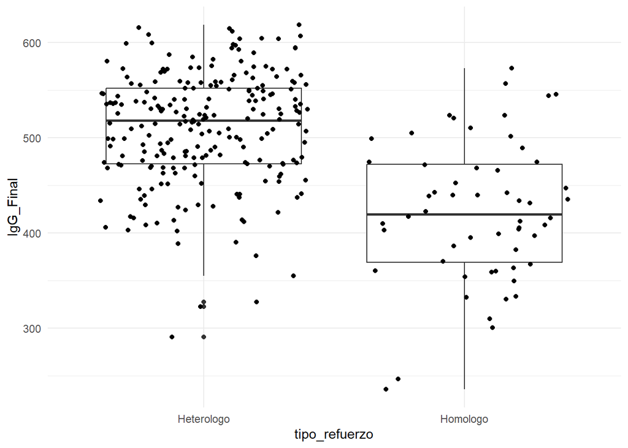

```r
p2 <- data_inmuno |>
  filter(tipo_refuerzo != "") |>
  ggplot(aes(x = tipo_refuerzo, y = IgG_Final)) +
  geom_boxplot() +
  geom_jitter() +
  theme_minimal()

p2
```

- p3:

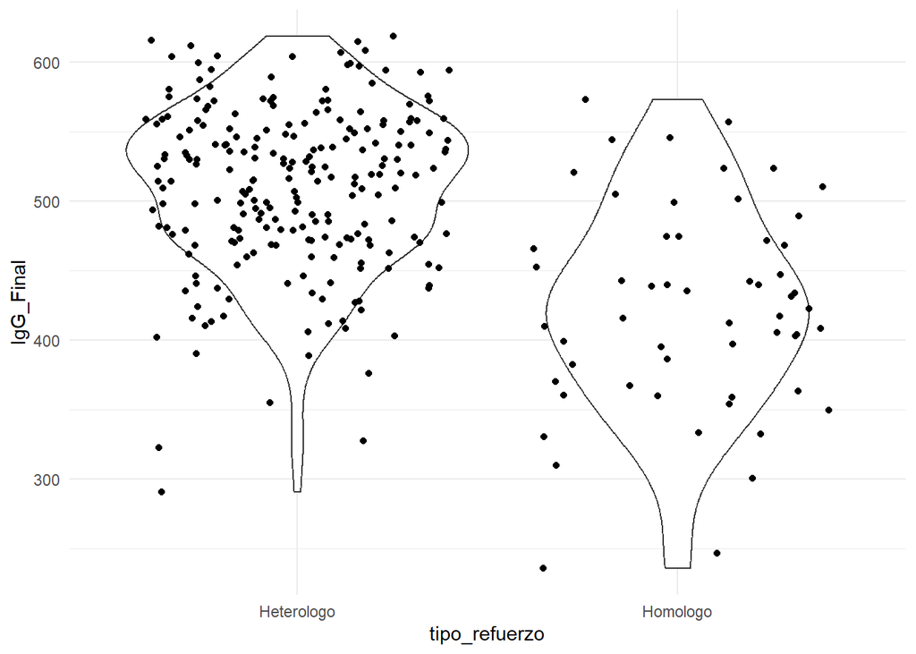

```r
p3 <- data_inmuno |>
  filter(tipo_refuerzo != "") |>
  ggplot(aes(x = tipo_refuerzo, y = IgG_Final)) +
  geom_violin() +
  geom_jitter() +
  theme_minimal()

p3
```

- p4:

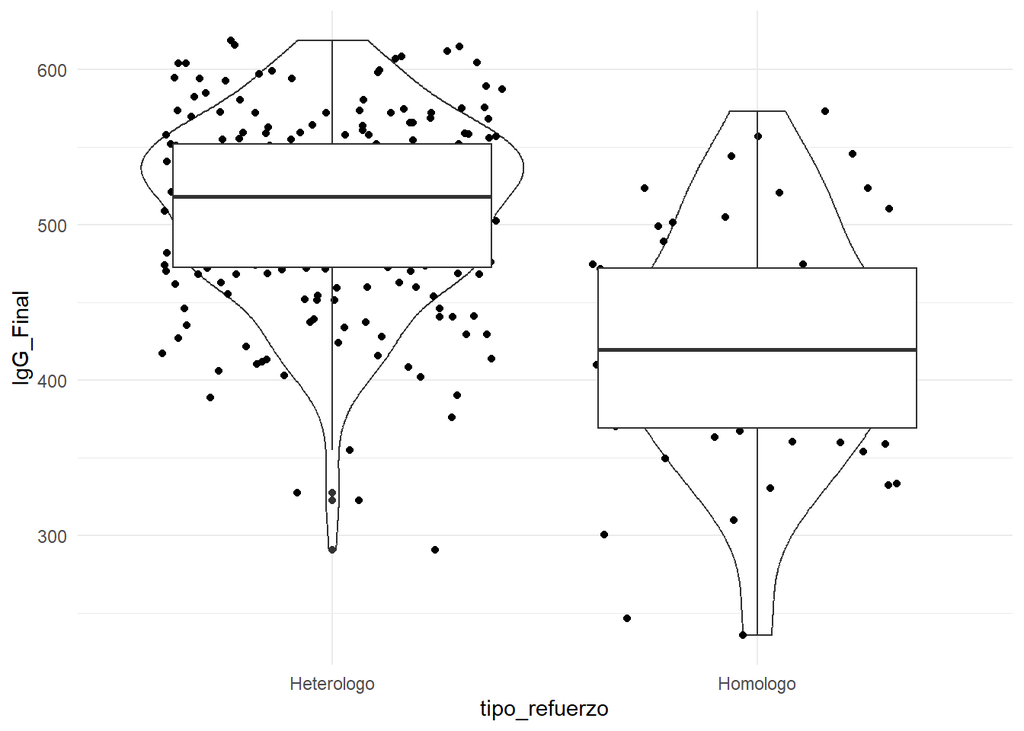

```r
p4 <- data_inmuno |>
  filter(tipo_refuerzo != "") |>
  ggplot(aes(x = tipo_refuerzo, y = IgG_Final)) +
  geom_violin() +
  geom_jitter() +
  geom_boxplot() +
  theme_minimal()

p4
```

### Ejercicio 20

Cree un gráfico de histograma del número de días desde el inicio de síntomas hasta la hospitalización de pacientes con ébola (days_onset_hosp). Controle los bins a 10. También cree un gráfico de densidad adicional.

*¿Cómo interpretarías los resultados encontrados? (discutirlo en la sesión)*

**Solución**

- Original:

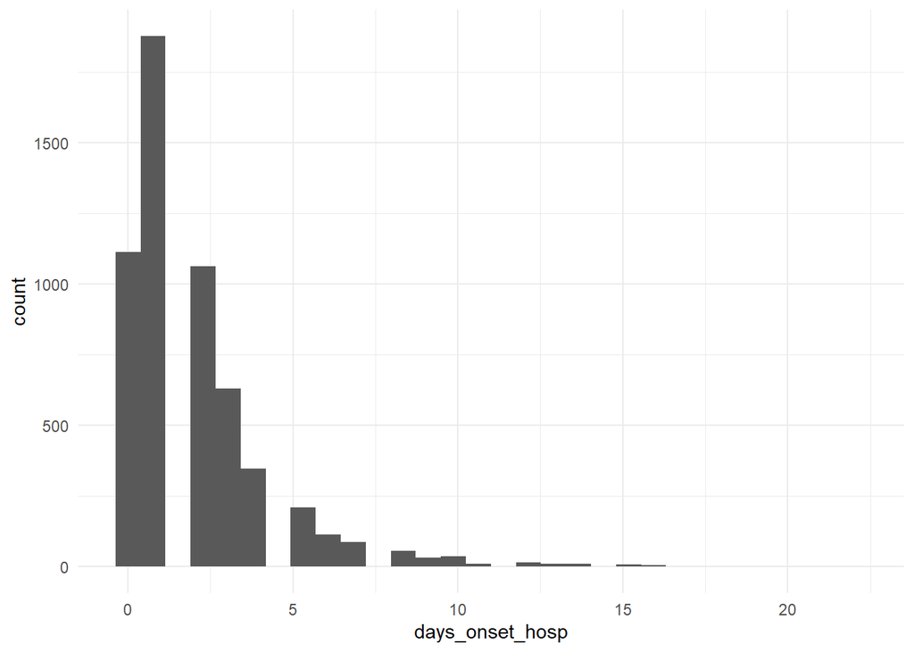

```r
data_ebola |>
  ggplot(aes(x = days_onset_hosp)) +
  geom_histogram() +
  theme_minimal()
```

- Cambiando bins:

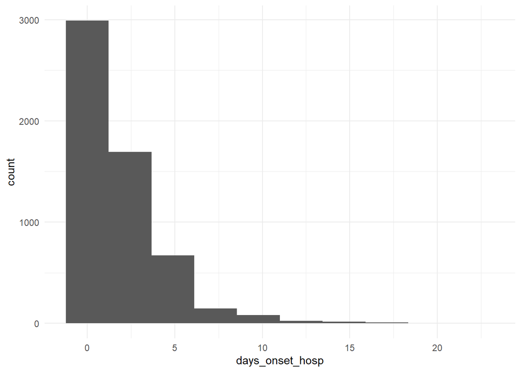

```r
data_ebola |>
  ggplot(aes(x = days_onset_hosp)) +
  geom_histogram(bins = 10) +
  theme_minimal()
```

- Creando gráfico de densidad:

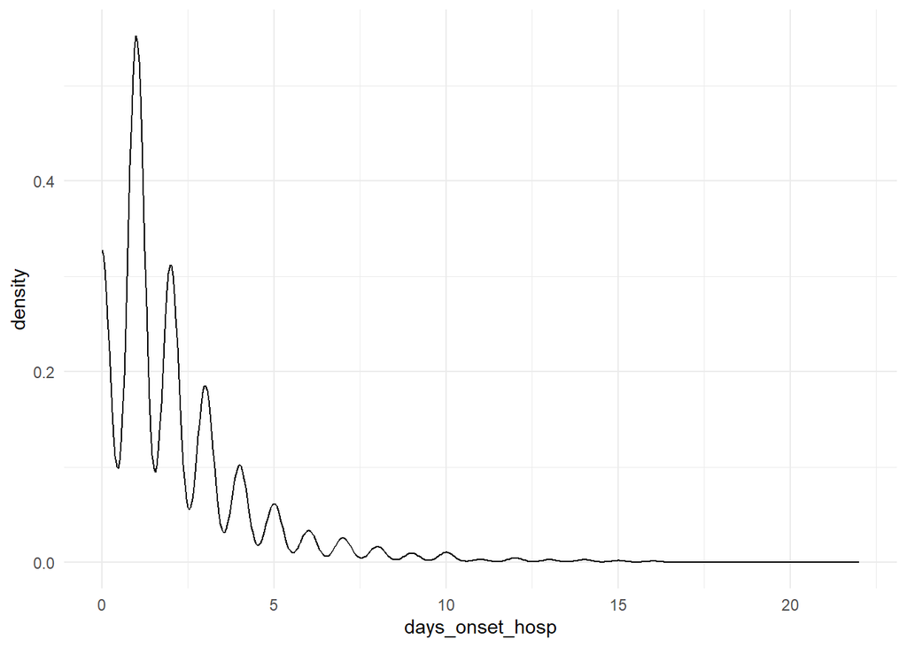

```r
data_ebola |>
  ggplot(aes(x = days_onset_hosp)) +
  geom_density() +
  theme_minimal()
```